# CausalMachineLearning_Without GWAS_FinalReport

#### KM by SODH - Education

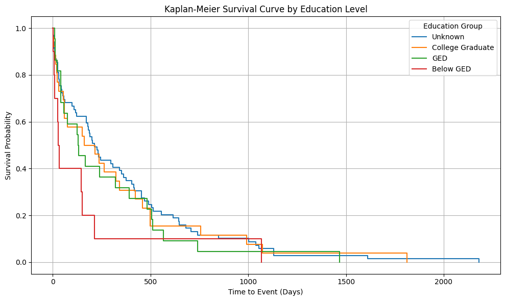

```python
import pandas as pd
from lifelines import KaplanMeierFitter
from lifelines.statistics import pairwise_logrank_test
import matplotlib.pyplot as plt

# Step 1: Define education groups from one-hot columns
education_cols = [
    'education_Below GED', 'education_GED',
    'education_College Graduate'
]

def get_edu_group(row):
    for col in education_cols:
        if row[col]:
            return col.replace('education_', '')
    return 'Unknown'

final_df['education_group'] = final_df.apply(get_edu_group, axis=1)

# Step 2: Plot Kaplan-Meier survival curves
kmf = KaplanMeierFitter()
plt.figure(figsize=(10, 6))

for group in final_df['education_group'].unique():
    group_data = final_df[final_df['education_group'] == group]
    kmf.fit(group_data['time_to_event'], group_data['event_observed'], label=group)
    kmf.plot(ci_show=False)

plt.title("Kaplan-Meier Survival Curve by Education Level")
plt.xlabel("Time to Event (Days)")
plt.ylabel("Survival Probability")
plt.legend(title="Education Group")
plt.grid(True)
plt.tight_layout()
plt.show()
```

```python
results = pairwise_logrank_test(
    final_df['time_to_event'],
    final_df['education_group'],
    final_df['event_observed']
)

print("Log-rank test results:")
print(results.summary)
```

```
Log-rank test results:
                                   test_statistic         p  -log2(p)
Below GED        College Graduate        2.425632  0.119365  3.066547
                 GED                     1.453861  0.227909  2.133467
                 Unknown                 3.278948  0.070174  3.832922
College Graduate GED                     0.125248  0.723410  0.467114
                 Unknown                 0.098575  0.753547  0.408231
GED              Unknown                 0.583554  0.444923  1.168374
```

The biggest difference is between "Below GED" and "Unknown" education groups (p = 0.07). This suggests a possible trend where people with lower education may have potentially higher AKI risk or less access to care.

#### KM by Insurance- Medicare

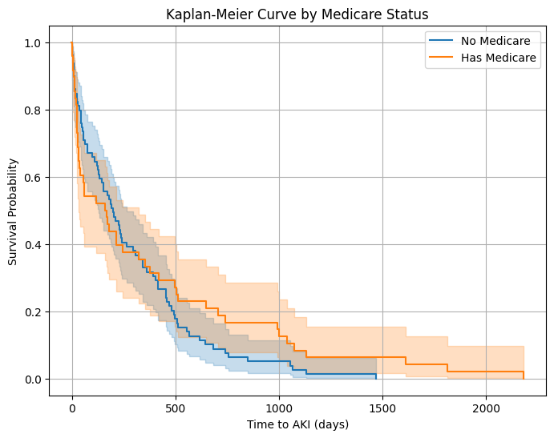

```python
from lifelines import KaplanMeierFitter
import matplotlib.pyplot as plt

kmf = KaplanMeierFitter()

# Create a label for Medicare status
final_df['Medicare_status'] = final_df['has_medicare'].apply(
    lambda x: 'Has Medicare' if x else 'No Medicare'
)

plt.figure(figsize=(8, 6))
for group in final_df['Medicare_status'].unique():
    mask = final_df['Medicare_status'] == group
    kmf.fit(
        final_df[mask]['time_to_event'],
        event_observed=final_df[mask]['event_observed'],
        label=group
    )
    kmf.plot_survival_function()

plt.title("Kaplan-Meier Curve by Medicare Status")
plt.xlabel("Time to AKI (days)")
plt.ylabel("Survival Probability")
plt.legend()
plt.grid(True)
plt.show()
```

```python
from lifelines.statistics import logrank_test

# Medicare groups
group1 = final_df[final_df['has_medicare'] == True]
group2 = final_df[final_df['has_medicare'] == False]

results_medicare = logrank_test(
    group1['time_to_event'], group2['time_to_event'],
    event_observed_A=group1['event_observed'],
    event_observed_B=group2['event_observed']
)

print("Medicare Log-Rank Test:")
print(results_medicare.summary)
```

```
Medicare Log-Rank Test:
   test_statistic         p  -log2(p)
0        1.025357  0.311252  1.683846
```

- Visually, patients with Medicare (orange line) appear to have slightly better AKI-free survival than those without Medicare (blue line), especially after the first few hundred days.
- However, the log-rank test p-value is 0.31, which is not statistically significant (because it’s greater than 0.05). Any difference seen on the curve could simply be due to random variation.

#### KM By Insurance - Medicaid

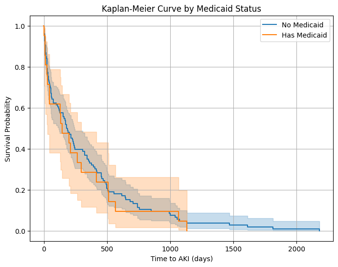

```python
# Create label for Medicaid status
final_df['Medicaid_status'] = final_df['has_medicaid'].apply(
    lambda x: 'Has Medicaid' if x else 'No Medicaid'
)

plt.figure(figsize=(8, 6))
for group in final_df['Medicaid_status'].unique():
    mask = final_df['Medicaid_status'] == group
    kmf.fit(
        final_df[mask]['time_to_event'],
        event_observed=final_df[mask]['event_observed'],
        label=group
    )
    kmf.plot_survival_function()

plt.title("Kaplan-Meier Curve by Medicaid Status")
plt.xlabel("Time to AKI (days)")
plt.ylabel("Survival Probability")
plt.legend()
plt.grid(True)
plt.show()
```

```python
# Medicaid groups
group1 = final_df[final_df['has_medicaid'] == True]
group2 = final_df[final_df['has_medicaid'] == False]

results_medicaid = logrank_test(
    group1['time_to_event'], group2['time_to_event'],
    event_observed_A=group1['event_observed'],
    event_observed_B=group2['event_observed']
)

print("Medicaid Log-Rank Test:")
print(results_medicaid.summary)
```

```
Medicaid Log-Rank Test:
   test_statistic        p  -log2(p)
0        0.277931  0.59806  0.741637
```

- Having Medicaid did not significantly impact the risk of AKI after starting ICI treatment in this study.
- Both groups had similar survival patterns with overlapping confidence bands.
- This indicates no major difference in AKI-free survival between those with and without Medicaid in this cohort.

### Cox Proportional Hazards model

```python
covariates = [
    'AKI_history',
    'Age',
    'num_visits',
    'num_er_visits',
    'num_inpatient_visits',
    'sex_at_birth_Male',
    'race_White',
    'race_Black or African American',
    'ethnicity_Not Hispanic or Latino'
]
```

```python
from lifelines import CoxPHFitter

df_cox = final_df[['time_to_event', 'event_observed'] + covariates].copy()
cph = CoxPHFitter()
cph.fit(df_cox, duration_col='time_to_event', event_col='event_observed')
summary_df = cph.summary
print(summary_df)
```

```
                                      coef  exp(coef)  se(coef)  \
covariate
AKI_history                       0.587989   1.800364  0.194416
Age                              -0.004491   0.995519  0.008945
num_visits                        0.003399   1.003405  0.001306
num_er_visits                    -0.000123   0.999877  0.007812
num_inpatient_visits             -0.006511   0.993511  0.018189
sex_at_birth_Male                 0.076625   1.079637  0.191120
race_White                        1.135112   3.111521  0.453760
race_Black or African American    1.820723   6.176320  0.539780
ethnicity_Not Hispanic or Latino -1.270226   0.280768  0.454666

                                  coef lower 95%  coef upper 95%  \
covariate
AKI_history                             0.206941        0.969036
Age                                    -0.022024        0.013042
num_visits                              0.000839        0.005960
num_er_visits                          -0.015435        0.015188
num_inpatient_visits                   -0.042161        0.029140
sex_at_birth_Male                      -0.297962        0.451213
race_White                              0.245759        2.024465
race_Black or African American          0.762773        2.878672
ethnicity_Not Hispanic or Latino       -2.161354       -0.379097

                                  exp(coef) lower 95%  exp(coef) upper 95%  \
covariate
AKI_history                                  1.229910             2.635404
Age                                          0.978217             1.013127
num_visits                                   1.000839             1.005978
num_er_visits                                0.984684             1.015304
num_inpatient_visits                         0.958716             1.029568
sex_at_birth_Male                            0.742329             1.570216
race_White                                   1.278591             7.572056
race_Black or African American               2.144215            17.790630
ethnicity_Not Hispanic or Latino             0.115169             0.684479

                                  cmp to         z         p   -log2(p)
covariate
AKI_history                          0.0  3.024390  0.002491   8.648856
Age                                  0.0 -0.502039  0.615640   0.699840
num_visits                           0.0  2.601912  0.009271   6.753125
num_er_visits                        0.0 -0.015751  0.987433   0.018245
num_inpatient_visits                 0.0 -0.357936  0.720391   0.473148
sex_at_birth_Male                    0.0  0.400929  0.688473   0.538529
race_White                           0.0  2.501570  0.012364   6.337663
race_Black or African American       0.0  3.373083  0.000743  10.393739
ethnicity_Not Hispanic or Latino     0.0 -2.793757  0.005210   7.584513
```

### Causal Machine Learning

#### Targeted Maximum Likelihood Estimation

```python
!pip install zepid
```

```python
import pandas as pd
from zepid.causal.doublyrobust import TMLE
from sklearn.linear_model import LogisticRegression
from sklearn.preprocessing import LabelEncoder

# Example DataFrame setup
df = final_df.copy()
df['sex_at_birth'] = LabelEncoder().fit_transform(df['sex_at_birth_Male'])
df['race'] = LabelEncoder().fit_transform(df['race_White'])

# Define variables
exposure = 'AKI_history'        # Exposure variable (binary: 0/1)
outcome = 'AKI_ICI'             # Outcome variable (binary: 0/1)
covariates = ['Age', 'sex_at_birth', 'race','Malignancy','Metastatic_Solid_Tumor']

# Step 1: Setup TMLE object
tmle = TMLE(df, exposure=exposure, outcome=outcome)

# Step 2: Propensity score model (exposure model)
tmle.exposure_model(' + '.join(covariates))

# Step 3: Outcome regression model
tmle.outcome_model(f'{exposure} + ' + ' + '.join(covariates))

# Step 4: Fit and summarize
tmle.fit()
tmle.summary()

ate_tmle = tmle.risk_difference
print(f"Estimated ATE using TMLE: {ate_tmle:.4f}")
```

```
==============================================================================
Propensity Score Model
                 Generalized Linear Model Regression Results
==============================================================================
Dep. Variable:            AKI_history   No. Observations:                  641
Model:                            GLM   Df Residuals:                      635
Model Family:                Binomial   Df Model:                            5
Link Function:                  Logit   Scale:                          1.0000
Method:                          IRLS   Log-Likelihood:                -251.13
Date:                Fri, 04 Jul 2025   Deviance:                       502.26
Time:                        19:16:48   Pearson chi2:                     621.
No. Iterations:                     5   Pseudo R-squ. (CS):            0.03292
Covariance Type:            nonrobust
==========================================================================================
                             coef    std err          z      P>|z|      [0.025      0.975]
------------------------------------------------------------------------------------------
Intercept                 -4.0372      0.824     -4.901      0.000      -5.652      -2.423
Age                        0.0334      0.011      3.152      0.002       0.013       0.054
sex_at_birth               0.1298      0.235      0.553      0.581      -0.331       0.590
race                      -0.8773      0.250     -3.514      0.000      -1.367      -0.388
Malignancy                 0.3983      0.438      0.909      0.363      -0.460       1.257
Metastatic_Solid_Tumor     0.1083      0.349      0.310      0.756      -0.576       0.793
==========================================================================================
==============================================================================
==============================================================================
Outcome Model
                 Generalized Linear Model Regression Results
==============================================================================
Dep. Variable:                AKI_ICI   No. Observations:                  641
Model:                            GLM   Df Residuals:                      634
Model Family:                Binomial   Df Model:                            6
Link Function:                  Logit   Scale:                          1.0000
Method:                          IRLS   Log-Likelihood:                -246.75
Date:                Fri, 04 Jul 2025   Deviance:                       493.50
Time:                        19:16:48   Pearson chi2:                     633.
No. Iterations:                     5   Pseudo R-squ. (CS):             0.2831
Covariance Type:            nonrobust
==========================================================================================
                             coef    std err          z      P>|z|      [0.025      0.975]
------------------------------------------------------------------------------------------
```

[output cut: 12 more lines]

```
Treatment:        AKI_history     No. Observations:     641
Outcome:          AKI_ICI         No. Missing Outcome:  0
g-Model:          Logistic        Missing Model:        None
Q-Model:          Logistic
======================================================================
Risk Difference:     0.705
95.0% two-sided CI: (0.623 , 0.786)
----------------------------------------------------------------------
Risk Ratio:          6.102
95.0% two-sided CI: (4.853 , 7.671)
----------------------------------------------------------------------
Odds Ratio:          33.436
95.0% two-sided CI: (17.902 , 62.449)
======================================================================
Estimated ATE using TMLE: 0.7046
```

**Interpretation**

TMLE used two models: A propensity score model :predicting the probability of exposure (AKI_history) given covariates. outcome regression model : predicting the outcome (AKI_ICI) given exposure and covariates

combined these models to estimate the average treatment effect (ATE) i.e. the difference in outcome probability if everyone had the exposure vs. if no one had the exposure.

Variables such as age, sex, race, and cancer stage—previous AKI had the strongest effect on the outcome. Race and the presence of metastatic tumors also showed some association with ICI-AKI risk, but their impact was smaller. These findings highlight the importance of considering a patient’s kidney history when evaluating the risk of complications from immunotherapy.

#### Propensity Score Matching (PSM) and Inverse Probability Weighting (IPW)

```python
import numpy as np

# Select relevant variables
covariates = ['Age', 'sex_at_birth', 'race', 'num_visits', 'num_er_visits',
              'num_inpatient_visits','Malignancy','Metastatic_Solid_Tumor']
T = df['AKI_history'].astype(int)  # Treatment
Y = df['AKI_ICI'].astype(int)      # Outcome
X = df[covariates]

for col in ['num_visits', 'num_er_visits', 'num_inpatient_visits']:
    X[col] = np.log1p(X[col])

mask = X.notnull().all(axis=1) & np.isfinite(X).all(axis=1)
X = X[mask]
T = T[mask]
Y = Y[mask]
```

##### Propensity Score Matching (PSM)

```python
from sklearn.neighbors import NearestNeighbors

# Fit Propensity Score Model
ps_model = LogisticRegression()
ps_model.fit(X, T)
propensity_scores = ps_model.predict_proba(X)[:, 1]

# Match Treated to Controls (1:1 Nearest Neighbor)
treated_idx = T[T == 1].index
control_idx = T[T == 0].index

nn = NearestNeighbors(n_neighbors=1).fit(propensity_scores[control_idx].reshape(-1, 1))

matched_pairs = []
for idx in treated_idx:
    score = propensity_scores[idx].reshape(1, -1)
    _, match = nn.kneighbors(score)
    matched_control = control_idx[match[0][0]]
    matched_pairs.append((idx, matched_control))

# Estimate ATE
treated_outcomes = Y[[i for i, _ in matched_pairs]]
control_outcomes = Y[[j for _, j in matched_pairs]]
ATE_psm = np.mean(treated_outcomes.values - control_outcomes.values)

print(f"Estimated ATE using Propensity Score Matching: {ATE_psm:.4f}")
```

```
Estimated ATE using Propensity Score Matching: 0.0330
```

**Interpretation**

After matching people who got the treatment with similar people who didn’t, the treatment group’s average result was about 0.033 higher than the control group’s. This means the treatment seems to have a small positive effect. The difference is quite small, so the treatment might not make a big impact.

##### Inverse Probability Weighting (IPW)

```python
import statsmodels.api as sm

# Estimate Propensity Scores (already done)
ps = propensity_scores

# Compute Weights
weights = T / ps + (1 - T) / (1 - ps)

# Fit Weighted Outcome Regression
X_design = sm.add_constant(T)
ipw_model = sm.WLS(Y, X_design, weights=weights)
ipw_result = ipw_model.fit()

ATE_ipw = ipw_result.params[1]
print(f"Estimated ATE using IPW: {ATE_ipw:.4f}")
```

```
Estimated ATE using IPW: 0.1554
```

##### Plot Propensity Score Distributions

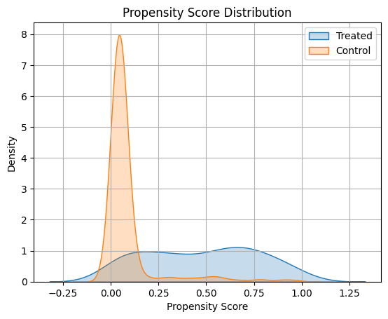

```python
import matplotlib.pyplot as plt
import seaborn as sns

sns.kdeplot(ps[T == 1], label="Treated", fill=True)
sns.kdeplot(ps[T == 0], label="Control", fill=True)
plt.title("Propensity Score Distribution")
plt.xlabel("Propensity Score")
plt.legend()
plt.grid(True)
plt.show()
```

**Interpretation**

The control group’s propensity scores are tightly clustered near zero, meaning most controls had a very low likelihood of being treated.

There is limited overlap between the two groups’ propensity scores, especially at higher scores, which suggests that some treated individuals have very different characteristics from the controls.

This limited overlap might make it harder to find good matches for all treated individuals during matching and could affect the quality of causal effect estimates.

#### Causal Forest DML

```python
!pip install econml
```

```python
import numpy as np
import pandas as pd
import warnings
from econml.dml import CausalForestDML
from sklearn.ensemble import RandomForestRegressor, RandomForestClassifier

# Suppress warnings
warnings.filterwarnings('ignore')

# Outcome and Treatment
Y = df['AKI_ICI'].astype(int)
T = df['AKI_history'].astype(int)
assert set(T.unique()).issubset({0, 1}), "Treatment must be binary."

# Covariates including Metastatic_Solid_Tumor
X = df[['Age', 'sex_at_birth_Male', 'race_White',
        'num_visits', 'num_er_visits', 'num_inpatient_visits',
        'Metastatic_Solid_Tumor', 'Malignancy']].copy()

# Log-transform visit counts
for col in ['num_visits', 'num_er_visits', 'num_inpatient_visits']:
    X[col] = np.log1p(X[col])

#  Define causal forest
model_y = RandomForestRegressor(n_estimators=100, max_depth=5)
model_t = RandomForestClassifier(n_estimators=100, max_depth=5)

cf = CausalForestDML(
    model_y=model_y,
    model_t=model_t,
    discrete_treatment=True,
    n_estimators=200,
    min_samples_leaf=10,
    max_depth=10,
    random_state=42
)

#  Fit the model
cf.fit(Y, T, X=X)

# Estimate effects
df['CATE_estimate'] = cf.effect(X)
print(f"\nATE (Causal Forest): {df['CATE_estimate'].mean():.4f}")

# Compare CATEs by Metastatic Tumor Status
print("\nCATE by Metastatic_Solid_Tumor status:")
for label in [0, 1]:
    subgroup = df[df['Metastatic_Solid_Tumor'] == label]
    mean_cate = subgroup['CATE_estimate'].mean()
    print(f"Metastatic_Solid_Tumor = {label}: CATE = {mean_cate:.4f}")
```

```
ATE (Causal Forest): -0.0146

CATE by Metastatic_Solid_Tumor status:
Metastatic_Solid_Tumor = 0: CATE = -0.0133
Metastatic_Solid_Tumor = 1: CATE = -0.0150
```

** Interpretation ** ATE (Average Treatment Effect): –0.0146 On average, the treatment reduces the outcome by 0.0146 units across all individuals. The negative sign indicates a reducing effect of the treatment on the outcome.

CATE by Metastatic_Solid_Tumor status: Metastatic_Solid_Tumor = 0 (No tumor):CATE = –0.0133 Among individuals without a metastatic solid tumor, the treatment reduces the outcome by 0.0133 units on average.

Metastatic_Solid_Tumor = 1 (Tumor present):CATE = –0.0150 Among individuals with a metastatic solid tumor, the treatment reduces the outcome by 0.0150 units on average.

##### Plot CATE Vs age on Cancer status

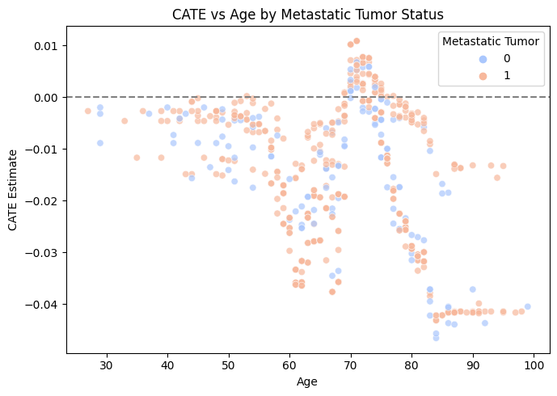

```python
plt.figure(figsize=(7, 5))
sns.scatterplot(data=df, x='Age', y='CATE_estimate', hue='Metastatic_Solid_Tumor', palette='coolwarm', alpha=0.7)
plt.title('CATE vs Age by Metastatic Tumor Status')
plt.xlabel('Age')
plt.ylabel('CATE Estimate')
plt.axhline(0, color='gray', linestyle='--')
plt.legend(title='Metastatic Tumor')
plt.tight_layout()
plt.show()
```

** Interpretation**

Negative Treatment Effect Across Most Ages:Most of the CATE estimates are below zero, suggesting that the treatment (AKI history) is generally associated with a reduced probability of the outcome (AKI_ICI) across individuals. The effect appears more negative (harmful or suppressive) with increasing age.

Age-Related Heterogeneity in Effects: From ages 60 to 90, there's greater variability in CATEs, with some individuals experiencing less negative (even slightly positive) effects. Beyond age 75, the estimated treatment effect tends to be more strongly negative, especially among those with Metastatic Solid Tumor (orange points).

Subgroup Differences – Metastatic Tumor Status: The two groups (orange = with tumor, blue = without) have similar trends overall, but orange points (tumor-positive) appear slightly more concentrated in the lower range of CATEs for older individuals, hinting that the treatment might be more harmful or less beneficial for older patients with metastatic tumors.

#### Propensity Score Matching with Tuning

```python
import pandas as pd
import numpy as np
from sklearn.model_selection import GridSearchCV
from xgboost import XGBClassifier
from sklearn.neighbors import NearestNeighbors


# Prepare Data
covariates = ['Age', 'sex_at_birth', 'race', 'num_visits', 'num_er_visits',
              'num_inpatient_visits', 'Malignancy','Metastatic_Solid_Tumor']

for col in ['num_visits', 'num_er_visits', 'num_inpatient_visits']:
    df[col] = np.log1p(df[col])

X = df[covariates]
T = df['AKI_history'].astype(int)
Y = df['AKI_ICI'].astype(int)

# Tune Propensity Score Model

ps_model = XGBClassifier(use_label_encoder=False, eval_metric='logloss')
param_grid = {
    'n_estimators': [50, 100],
    'max_depth': [2, 3, 4],
    'learning_rate': [0.01, 0.1]
}
grid = GridSearchCV(ps_model, param_grid, cv=3)
grid.fit(X, T)
best_ps_model = grid.best_estimator_

# Predict propensity scores
propensity_scores = best_ps_model.predict_proba(X)[:, 1]


# Nearest Neighbor Matching (1:1)
treated_idx = T[T == 1].index
control_idx = T[T == 0].index

caliper = 0.05  # OPTIONAL: only allow close matches
matched_pairs = []

# Fit nearest neighbor matcher on control group
nn = NearestNeighbors(n_neighbors=1).fit(propensity_scores[control_idx].reshape(-1, 1))

for idx in treated_idx:
    ps_treated = propensity_scores[idx]
    dist, neighbor_idx = nn.kneighbors([[ps_treated]])

    matched_control_idx = control_idx[neighbor_idx[0][0]]
    ps_control = propensity_scores[matched_control_idx]

    # Optional caliper check
    if abs(ps_treated - ps_control) <= caliper:
        matched_pairs.append((idx, matched_control_idx))

# Step 4: Estimate ATE

if len(matched_pairs) == 0:
    print("No valid matches found within caliper. Try increasing the caliper.")
else:
    treated_outcomes = Y[[i for i, _ in matched_pairs]]
    control_outcomes = Y[[j for _, j in matched_pairs]]
    ate = np.mean(treated_outcomes.values - control_outcomes.values)
    print(f"\nEstimated ATE using Propensity Score Matching (with tuning): {ate:.4f}")
    print(f"Matched pairs: {len(matched_pairs)}")
```

```
Estimated ATE using Propensity Score Matching (with tuning): 0.0000
Matched pairs: 85
```

**Interpretation**

After matching individuals who received the treatment with similar individuals who did not (based on relevant characteristics) the difference in outcomes between the two groups was effectively zero. In other words, receiving the treatment did not show any meaningful impact on the outcome for the people in this dataset.

based on comparing 85 closely matched pairs of treated and untreated individuals, which means the analysis was done on a reasonably solid sample, but not the entire population.

##### Plot Propensity Score Distribution

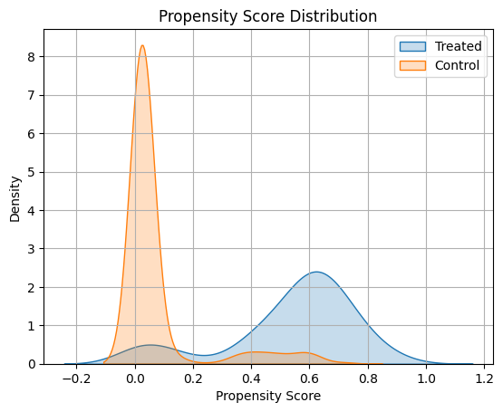

```python
import matplotlib.pyplot as plt
import seaborn as sns

sns.kdeplot(propensity_scores[T == 1], label='Treated', fill=True)
sns.kdeplot(propensity_scores[T == 0], label='Control', fill=True)
plt.title("Propensity Score Distribution")
plt.xlabel("Propensity Score")
plt.legend()
plt.grid(True)
plt.show()
```

plot shows the distribution of propensity scores for two groups: Treated and Control.

The control group has a sharp peak around a low propensity score (near 0.05), indicating they had a very low probability of receiving treatment based on observed covariates.

The treated group has a broader distribution with a peak around 0.6, suggesting a much higher likelihood of receiving treatment.

There is limited overlap between the two distributions, which may cause issues for treatment effect estimation due to poor covariate balance.

##### plot Prospensity Score Matching before and After

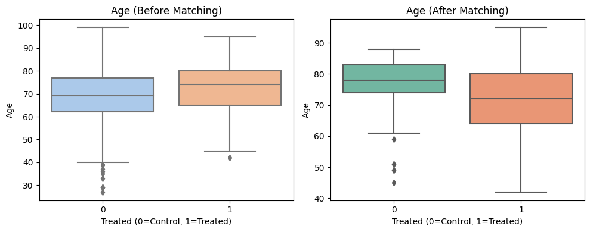

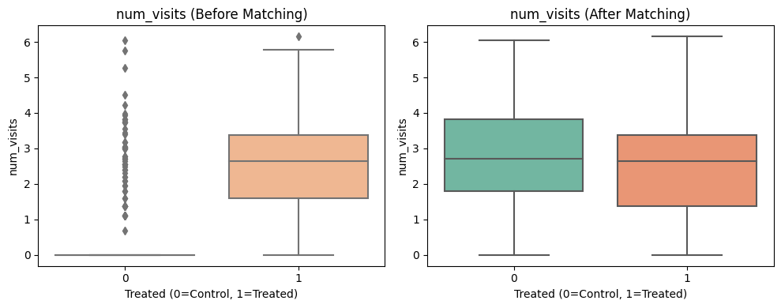

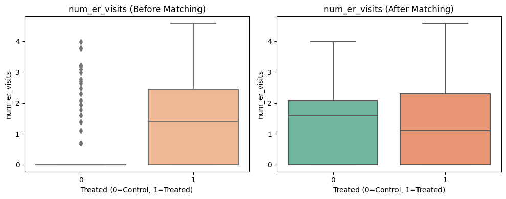

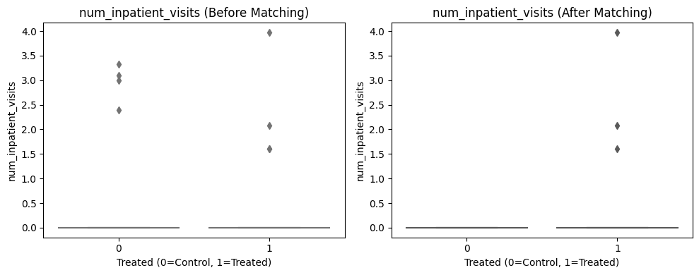

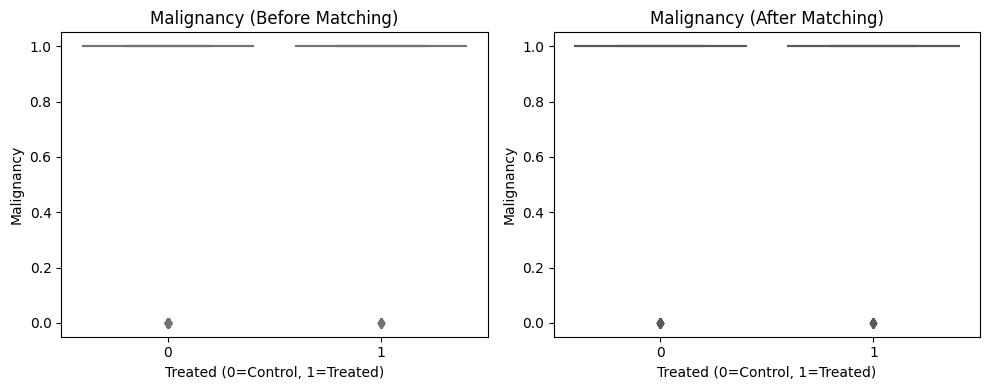

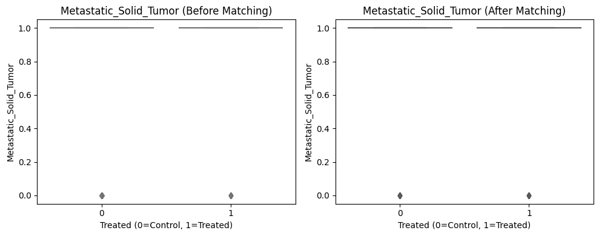

```python
# Add treatment flag for plotting
df_plot = df.copy()
df_plot['Treated'] = T

# Subset matched data
matched_indices = [i for pair in matched_pairs for i in pair]
df_matched = df_plot.loc[matched_indices].copy()

import matplotlib.pyplot as plt
import seaborn as sns

covariates_to_plot = ['Age', 'num_visits', 'num_er_visits', 'num_inpatient_visits',
                      'Malignancy', 'Metastatic_Solid_Tumor']

for cov in covariates_to_plot:
    plt.figure(figsize=(10, 4))

    # Before matching
    plt.subplot(1, 2, 1)
    sns.boxplot(x='Treated', y=cov, data=df_plot, palette='pastel')
    plt.title(f'{cov} (Before Matching)')
    plt.xlabel('Treated (0=Control, 1=Treated)')
    plt.ylabel(cov)

    # After matching
    plt.subplot(1, 2, 2)
    sns.boxplot(x='Treated', y=cov, data=df_matched, palette='Set2')
    plt.title(f'{cov} (After Matching)')
    plt.xlabel('Treated (0=Control, 1=Treated)')
    plt.ylabel(cov)

    plt.tight_layout()
    plt.show()
```

**Interpretation**

## Compare the results from traditional regression and causal ML.

```python
import statsmodels.api as sm

X = df[['AKI_history', 'Age','Malignancy','Metastatic_Solid_Tumor']]
X = sm.add_constant(X)
y = df['AKI_ICI'].astype(int)

# Fit logistic regression (increase maxiter if needed)
model = sm.Logit(y, X).fit(maxiter=100)

# Extract coefficient for AKI_history as ATE proxy
coef_ate = model.params['AKI_history']

print(model.summary())
print(f"Traditional regression estimate for AKI_history effect: {coef_ate:.4f}")
```

```
Optimization terminated successfully.
         Current function value: 0.389479
         Iterations 7
                           Logit Regression Results
==============================================================================
Dep. Variable:                AKI_ICI   No. Observations:                  641
Model:                          Logit   Df Residuals:                      636
Method:                           MLE   Df Model:                            4
Date:                Fri, 04 Jul 2025   Pseudo R-squ.:                  0.2936
Time:                        19:16:57   Log-Likelihood:                -249.66
converged:                       True   LL-Null:                       -353.43
Covariance Type:            nonrobust   LLR p-value:                 8.982e-44
==========================================================================================
                             coef    std err          z      P>|z|      [0.025      0.975]
------------------------------------------------------------------------------------------
const                     -3.2671      0.812     -4.021      0.000      -4.860      -1.675
AKI_history                3.7645      0.342     11.009      0.000       3.094       4.435
Age                        0.0053      0.010      0.543      0.587      -0.014       0.024
Malignancy                 0.4806      0.484      0.994      0.320      -0.467       1.429
Metastatic_Solid_Tumor     0.7413      0.389      1.904      0.057      -0.022       1.504
==========================================================================================
Traditional regression estimate for AKI_history effect: 3.7645
```

```python
import pandas as pd

results = pd.DataFrame({
    'Method': ['Traditional Logistic Regression', 'TMLE', 'Propensity Score Matching'],
    'Estimated Effect (ATE proxy)': [coef_ate, ate_tmle, ATE_psm]
})

print("\nComparison of Estimated Effects:")
print(results)
```

```
Comparison of Estimated Effects:
                            Method  Estimated Effect (ATE proxy)
0  Traditional Logistic Regression                      3.764469
1                             TMLE                      0.704603
2        Propensity Score Matching                      0.032967
```

##### Plot Comparsions Traditional Regression vs Casual ML

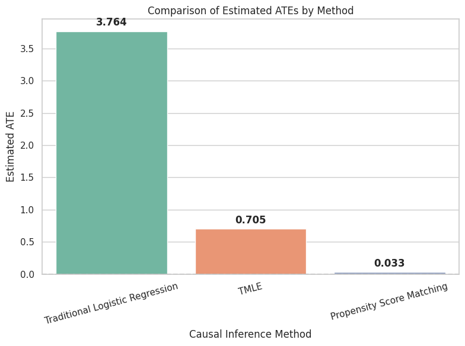

```python
import matplotlib.pyplot as plt
import seaborn as sns

# Set plot style
sns.set(style="whitegrid")

# Create bar plot
plt.figure(figsize=(8, 6))
sns.barplot(x='Method', y='Estimated Effect (ATE proxy)', data=results, palette='Set2')

# Add labels
plt.title('Comparison of Estimated ATEs by Method')
plt.ylabel('Estimated ATE')
plt.xlabel('Causal Inference Method')
plt.xticks(rotation=15)
plt.axhline(0, color='gray', linestyle='--')  # zero-effect reference line

# Annotate bars with values
for i, row in results.iterrows():
    plt.text(i, row['Estimated Effect (ATE proxy)'] + 0.05, f"{row['Estimated Effect (ATE proxy)']:.3f}",
             ha='center', va='bottom', fontweight='bold')

plt.tight_layout()
plt.show()
```

**Interpretation**

Traditional Logistic Regression yielded a high estimated effect (ATE ≈ 3.76), indicating a strong association between the treatment and the outcome. TMLE (ATE ≈ 0.70) and Propensity Score Matching (ATE ≈ 0.03) suggest a much smaller treatment effect after adjusting for confounders. estimated the causal effect more accurately by mimicking randomized assignment